### Data Description

The source of the data is the Kaggle’s “Per Capita Income by County (2021) vs. Education” dataset. The data set contains information on county-level statistics, including per capita personal income, the number of associate and bachelor degrees, and the percentage of the population with associate and bachelor degrees.

### Data Clean

The code first reads in the data and removes any missing values. Then, it scales the percentage of the population with associate and bachelor degrees to a range between 0 and 1.

```r
df<-read.csv("US counties - education vs per capita personal income - results-20221227-213216.csv")
df <- df[, -c(1,2, 3, 4,5)]
df <- na.omit(df)
df$bachelor_degree_percentage_2015_2019 <- df$bachelor_degree_percentage_2015_2019 / 100
df$associate_degree_percentage_2016_2020 <- df$associate_degree_percentage_2016_2020 / 100
str(df)
```

```
## 'data.frame':    3006 obs. of  5 variables:
##  $ per_capita_personal_income_2021      : int  107603 81306 89593 86380 195543 90254 198939 74994 107698 164118 ...
##  $ associate_degree_numbers_2016_2020   : int  19573 2766 45834 42538 167960 52006 2932 17907 32995 44228 ...
##  $ bachelor_degree_numbers_2016_2020    : int  132394 9098 135876 136792 777483 160853 8459 55545 91780 114604 ...
##  $ associate_degree_percentage_2016_2020: num  0.112 0.205 0.212 0.195 0.134 ...
##  $ bachelor_degree_percentage_2015_2019 : num  0.758 0.676 0.63 0.627 0.622 ...
```

### EDA

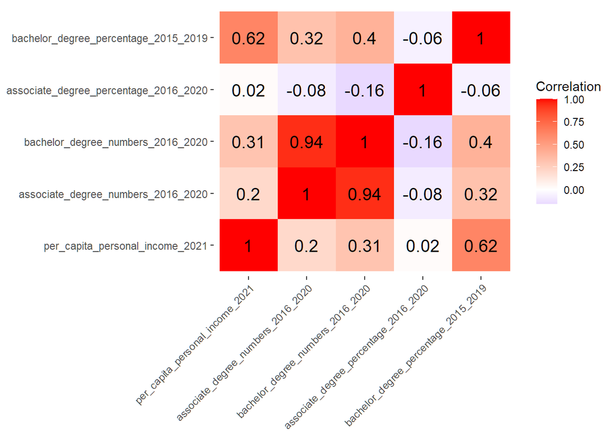

```r
library(reshape2)
library(ggplot2)
library(ISLR)
require(boot)
cor_df <- round(cor(df), 2)
melted_cor <- melt(cor_df)
ggplot(data = melted_cor, aes(x=Var1, y=Var2, fill=value)) +
  geom_tile() +
  geom_text(aes(Var2, Var1, label = value), size = 5) +
  scale_fill_gradient2(low = "blue", high = "red"
                       , name="Correlation") +
  theme(axis.title.x = element_blank(),
        axis.title.y = element_blank(),
        panel.background = element_blank(),
        axis.text.x = element_text(angle = 45, hjust=1))
```

### Regression

#### Linear Regression on all variables

```r
lm.fit <- lm(per_capita_personal_income_2021 ~ associate_degree_numbers_2016_2020 +
                                               bachelor_degree_numbers_2016_2020 +
                                               associate_degree_percentage_2016_2020 +
                                               bachelor_degree_percentage_2015_2019, data = df)
summary(lm.fit)
```

```
##
## Call:
## lm(formula = per_capita_personal_income_2021 ~ associate_degree_numbers_2016_2020 +
##     bachelor_degree_numbers_2016_2020 + associate_degree_percentage_2016_2020 +
##     bachelor_degree_percentage_2015_2019, data = df)
##
## Residuals:
##    Min     1Q Median     3Q    Max
## -44574  -5285  -1412   3173 239166
##
## Coefficients:
##                                         Estimate Std. Error t value Pr(>|t|)
## (Intercept)                            2.482e+04  1.343e+03  18.485  < 2e-16
## associate_degree_numbers_2016_2020    -1.253e-01  9.834e-03 -12.738  < 2e-16
## bachelor_degree_numbers_2016_2020      1.062e-01  7.682e-03  13.820  < 2e-16
## associate_degree_percentage_2016_2020  3.087e+04  3.987e+03   7.742 1.33e-14
## bachelor_degree_percentage_2015_2019   8.427e+04  2.402e+03  35.080  < 2e-16
##
## (Intercept)                           ***
## associate_degree_numbers_2016_2020    ***
## bachelor_degree_numbers_2016_2020     ***
## associate_degree_percentage_2016_2020 ***
## bachelor_degree_percentage_2015_2019  ***
## ---
## Signif. codes:  0 '***' 0.001 '**' 0.01 '*' 0.05 '.' 0.1 ' ' 1
##
## Residual standard error: 11170 on 3001 degrees of freedom
## Multiple R-squared:  0.4226, Adjusted R-squared:  0.4219
## F-statistic: 549.2 on 4 and 3001 DF,  p-value: < 2.2e-16
```

```r
ypred <- predict(lm.fit, newdata = df)
y<-df$per_capita_personal_income_2021
res <- y-ypred
RMSE <- sqrt(mean(res^2))
SST <- sum((y - mean(ypred))^2)
SSR <- sum(res^2)
R_squared <- 1 - (SSR/SST)
```

```r
# Print RMSE
cat("RMSE:",mean(res**2)**0.5, "\n")
```

```
## RMSE: 11160.51
```

```r
# Print R-squared value
cat("R-squared:", R_squared, "\n")
```

```
## R-squared: 0.4226334
```

```r
cat("Errors:\n")
```

```
## Errors:
```

```r
print(mean(res))
```

```
## [1] -5.769123e-11
```

```r
png("linear.png")
par(mfrow = c(2, 2))
plot(lm.fit)
dev.off()
```

#### Polynomial Regression on significant numeric variables of linear regression

```r
cv.error=rep(0,5)
loocv=function(fit){
  h =lm.influence(fit)$h
  mean((residuals(fit)/(1-h))^2)
  }
degree =1:5

for (d in degree){
  glm.fit=glm(per_capita_personal_income_2021~poly(bachelor_degree_percentage_2015_2019,d)+poly(associate_degree_numbers_2016_2020,d)+poly(bachelor_degree_numbers_2016_2020,d)+poly(associate_degree_percentage_2016_2020,d),data=df)
  cv.error[d]=loocv(glm.fit)
}
print(cv.error)
```

```
## [1]   126052913   122562678   201466205   695425071 56402566736
```

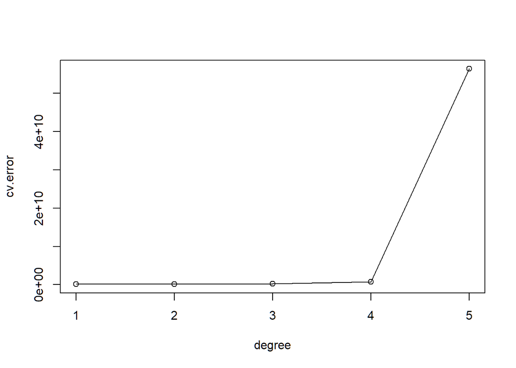

```r
plot(degree,cv.error, type='o')
```

By looking at the graph we can conclude that a quadratic model will be a good fit.

```r
glm.fit=glm(per_capita_personal_income_2021~poly(bachelor_degree_percentage_2015_2019,2)+poly(associate_degree_numbers_2016_2020,2)+poly(bachelor_degree_numbers_2016_2020,2)+poly(associate_degree_percentage_2016_2020,2),data=df)
summary(glm.fit)
```

```
##
## Call:
## glm(formula = per_capita_personal_income_2021 ~ poly(bachelor_degree_percentage_2015_2019,
##     2) + poly(associate_degree_numbers_2016_2020, 2) + poly(bachelor_degree_numbers_2016_2020,
##     2) + poly(associate_degree_percentage_2016_2020, 2), data = df)
##
## Deviance Residuals:
##    Min      1Q  Median      3Q     Max
## -47029   -5215   -1120    3352  236352
##
## Coefficients:
##                                                  Estimate Std. Error t value
## (Intercept)                                       53308.5      200.2 266.329
## poly(bachelor_degree_percentage_2015_2019, 2)1   436850.9    13590.0  32.145
## poly(bachelor_degree_percentage_2015_2019, 2)2    29900.3    13669.6   2.187
## poly(associate_degree_numbers_2016_2020, 2)1    -326889.4    37525.0  -8.711
## poly(associate_degree_numbers_2016_2020, 2)2     215589.7    52314.4   4.121
## poly(bachelor_degree_numbers_2016_2020, 2)1      390657.6    39165.6   9.975
## poly(bachelor_degree_numbers_2016_2020, 2)2     -227267.0    53618.2  -4.239
## poly(associate_degree_percentage_2016_2020, 2)1  104255.1    12293.5   8.481
## poly(associate_degree_percentage_2016_2020, 2)2   89332.3    11634.8   7.678
##                                                 Pr(>|t|)
## (Intercept)                                      < 2e-16 ***
## poly(bachelor_degree_percentage_2015_2019, 2)1   < 2e-16 ***
## poly(bachelor_degree_percentage_2015_2019, 2)2    0.0288 *
## poly(associate_degree_numbers_2016_2020, 2)1     < 2e-16 ***
## poly(associate_degree_numbers_2016_2020, 2)2    3.87e-05 ***
## poly(bachelor_degree_numbers_2016_2020, 2)1      < 2e-16 ***
## poly(bachelor_degree_numbers_2016_2020, 2)2     2.32e-05 ***
## poly(associate_degree_percentage_2016_2020, 2)1  < 2e-16 ***
## poly(associate_degree_percentage_2016_2020, 2)2 2.17e-14 ***
## ---
## Signif. codes:  0 '***' 0.001 '**' 0.01 '*' 0.05 '.' 0.1 ' ' 1
##
## (Dispersion parameter for gaussian family taken to be 120432340)
##
##     Null deviance: 6.4849e+11  on 3005  degrees of freedom
## Residual deviance: 3.6094e+11  on 2997  degrees of freedom
## AIC: 64473
##
## Number of Fisher Scoring iterations: 2
```

```r
ypred_poly <- predict(glm.fit, newdata = df)
y<-df$per_capita_personal_income_2021
res_poly <- y-ypred_poly
RMSE_poly <- sqrt(mean(res_poly^2))
SST_poly <- sum((y - mean(ypred_poly))^2)
SSR_poly <- sum(res_poly^2)
R_squared_poly <- 1 - (SSR_poly/SST_poly)
```

```r
# Print RMSE
cat("poly RMSE:",mean(res_poly**2)**0.5, "\n")
```

```
## poly RMSE: 10957.73
```

```r
# Print R-squared value
cat("poly R-squared:", R_squared_poly, "\n")
```

```
## poly R-squared: 0.4434241
```

```r
cat("poly Errors:\n")
```

```
## poly Errors:
```

```r
print(mean(res_poly))
```

```
## [1] -1.794231e-11
```

```r
png("poly.png")
par(mfrow = c(2, 2))
plot(glm.fit)
dev.off()
```

#### Model Comparison

```r
# Print RMSE
cat("RMSE:",mean(res**2)**0.5, "\n")
```

```
## RMSE: 11160.51
```

```r
# Print R-squared value
cat("R-squared:", R_squared, "\n")
```

```
## R-squared: 0.4226334
```

```r
cat("Errors:\n")
```

```
## Errors:
```

```r
print(mean(res))
```

```
## [1] -5.769123e-11
```

```r
cat("poly RMSE:",mean(res_poly**2)**0.5, "\n")
```

```
## poly RMSE: 10957.73
```

```r
# Print R-squared value
cat("poly R-squared:", R_squared_poly, "\n")
```

```
## poly R-squared: 0.4434241
```

```r
cat("poly Errors:\n")
```

```
## poly Errors:
```

```r
print(mean(res_poly))
```

```
## [1] -1.794231e-11
```

#### Method

We constructed a linear regression model on this dataset with personal income per capita as the dependent variable and the number and percentage of degrees as independent variables. The output includes intercepts, coefficients, standard errors, t-values, and p-values for each independent variable, and Residual standard error, multiple R-squared, and adjusted R-squared values for the entire model. Afterwards, a polynomial regression analysis with an order of 1 to 5 was carried out to further explore the relationship between educational attainment and per capita income.

#### Conclusion

The results of linear regression analysis show that there is a positive and statistically significant relationship between educational attainment and per capita personal income. An R-squared value of 0.42 indicates that the model explains 42% of the variability in per capita personal income across counties. Additionally, a root mean square error (RMSE) of 11,160.51 indicates that the average difference between the predicted and actual value of personal income per capita is $11,160.51. Results of the polynomial regression analysis indicated that the second-order polynomial model provided the best fit to the data, with an R-squared value of 0.44 and a low RMSE of 10,957.73. Overall, the analysis shows that higher educational attainment is associated with higher levels of per capita personal income at the U.S. county level.